# Question

A metal object is heated and then placed in front of a fan to cool. A few internal temperature readings were taken over the following minutes.

| Time ($t$ in minutes) | Temperature ($T$ in °C) |
| --- | --- |
| 1 | 82 |
| 1.4 | 76 |
| 1.8 | 75 |
| 2.6 | 69 |
| 3.8 | 52 |
| 4.7 | 52 |
| 5.3 | 50 |
| 5.7 | 49 |

We can assume that the temperature **roughly** follows [Newton’s law of cooling](https://en.wikipedia.org/wiki/Newton%27s_law_of_cooling).

$$T(t) ~\approx~
\left(T_0-T_{\mathrm{env}}\right)e^{-rt}+T_{\mathrm{env}}$$

where $T_0$ is the initial temperature of the object (at $t=0$); $T_\mathrm{env}$ is the temperature of the air; $T(t)$ is the temperature of the object as a function of time; $t$ is the time; and $r$ is a rate constant which depends on the size/material of the object and strength of the fan.

Using Desmos, make a custom regression by first pasting the data and then typing the following formula:

$$y_1 \sim (T_0-T_{\mathrm{env}})e^{-r
x_1}+T_{\mathrm{env}}$$

Based on the regression, you should see the temperature [asymptotically](https://en.wikipedia.org/wiki/Asymptote) approaches a specific temperature as time approaches infinity. What is this asymptotic temperature suggested by the regression?

# Solution

Your least-square regression should give a best-fit curve with the following parameters:

$$T_0 ~=~ 97.5392445$$
$$T_\mathrm{env} ~=~ 34.511481$$
$$r~=~0.2722298$$

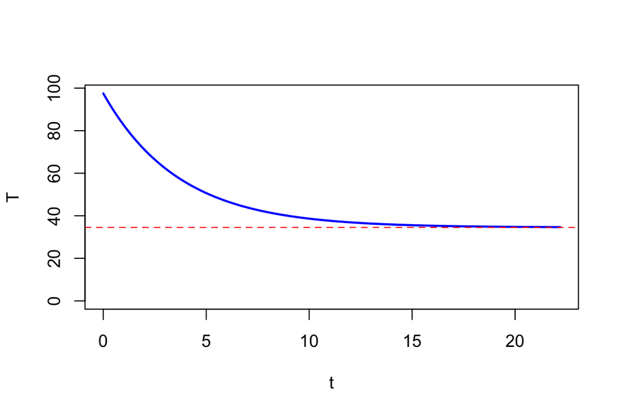

You should see that in the long run, as $t\to \infty$, if the model is accurate, the temperature will approach 34.5°C (approximately).

# Meta-information

extype: num exsolution: 34.5 exname: newtons_cooling_fit extol: 0.1